# Predicting the winner and classifying players for Dota2

# Introduction

The goal of the project is to predict the outcome of the match based on the heroes picked and to classify different kinds of players in the game based on win rate versus pick rate.

# Data Description

The data set consist of 117 columns with 92.6k rows. For the purpose of this project I removed the columns ClusterID, Game_Mode, and Game_Type. The remaining columns are Team_Won and all 113 heroes at the time this data was gathered. Each row of the dataset is a single game with the following features (in the order in the vector): 1. Team won the game (1 or -1) 2. Cluster ID (related to location) 3. Game mode (eg All Pick) 4. Game type (eg. Ranked) 5 - end: Each element is an indicator for a hero. Value of 1 indicates that a player from team ‘1’ played as that hero and ‘-1’ for the other team. Hero can be selected by only one player each game. This means that each row has five ‘1’ and five ‘-1’ values.

```r
library(readr)
library(e1071)        # SVM
library(kernlab)      # assist with SVM feature selection
library(tidyverse)    # data transformation and visualization
library(rpart)        #Classification Tree
library(randomForest) #Random Forest Classification

test <- read_csv("E:/Users/lozan/Desktop/DOTA/dota2Test.csv")
train <-read_csv("E:/Users/lozan/Desktop/DOTA/dota2Train.csv")
```

```r
#Only using 5% of the data because dataset is too large
Train2<-train[1:4632,c(-2,-3,-4,-28)]
```

```r
#Need to factor numerical values in Team_Won inorder for it to work in the rpart algorithm
Train2$Team_Won <- factor(Train2$Team_Won)
#Removing any possible NAs
Train2 <- na.omit(Train2)
```

# Methods

## SVM

```r
#Sepearating data into test set and train set
index <- 1:nrow(Train2)
testindex <- sample(index , trunc(length(index)/3))
testset <- Train2[testindex,]
trainset <- Train2[-testindex,]
#SVM
svm.model <- svm(Team_Won ~., data = trainset, cost=100, gamma=1,scale = FALSE,kernel="linear")
summary(svm.model)
```

```
Call:
svm(formula = Team_Won ~ ., data = trainset, cost = 100, gamma = 1, kernel = "linear", scale = FALSE)


Parameters:
   SVM-Type:  C-classification
 SVM-Kernel:  linear
       cost:  100
      gamma:  1

Number of Support Vectors:  2498

 ( 1254 1244 )


Number of Classes:  2

Levels:
 -1 1
```

```r
svm.pred <- predict(svm.model, testset[,-1])
svm_confusion<-table(svm.pred,testset$Team_Won)
svm_confusion
```

```
svm.pred  -1   1
      -1 359 285
      1  355 545
```

```r
(svm_confusion[1,1]+svm_confusion[2,2])/(sum(svm_confusion))
```

```
[1] 0.5854922
```

## PCA

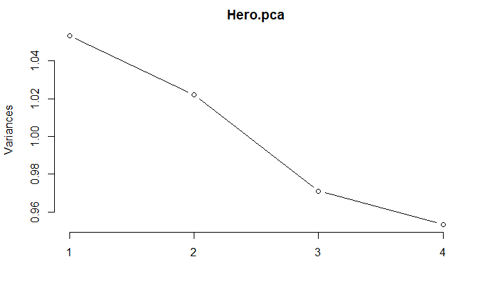

```r
#The reason I am using PCA is to try and visualize the data in a lower dimension because trying to plot my svm model would be difficult because of how many explanatory variables there are. I came to realize the biplot does not make sense to me, so it does not apply to my project, but I did attempt to implement it.
library(devtools)
library(ggbiplot)
#Some variables had zero so I had to remove them
Hero_Rz <- Train2[,apply(Train2, 2, var, na.rm=TRUE) != 0]
random_hero<- sample(2:108,1)
random_hero2<-random_hero+3
Hero.pca<-prcomp(Hero_Rz[,random_hero:random_hero2],center = FALSE,scale. = TRUE)
plot(Hero.pca,type="l")
```

```r
summary(Hero.pca)
```

```
Importance of components%s:
                          PC1    PC2    PC3    PC4
Standard deviation     1.0264 1.0111 0.9853 0.9764
Proportion of Variance 0.2634 0.2556 0.2427 0.2383
Cumulative Proportion  0.2634 0.5189 0.7617 1.0000
```

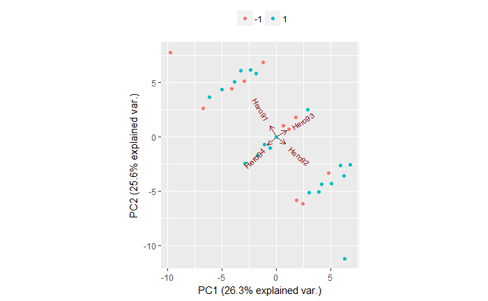

```r
ggbiplot(Hero.pca, obs.scale = 1, var.scale = 1,
              groups = Train2$Team_Won, ellipse = FALSE,
                circle = FALSE) + scale_color_discrete(name = '') + theme(legend.direction = 'horizontal',
               legend.position = 'top')
```

## Tuned SVM

```r
set.seed(123)
svm_tune<-tune.svm(Team_Won~.,data = trainset,kernel="linear",cost=c(0.001,0.01, 0.1,1,5,10),scale=FALSE)
```

```r
summary(svm_tune)
```

```
Parameter tuning of svm:

- sampling method: 10-fold cross validation

- best parameters:
 cost
   10

- best performance: 0.4038425

- Detailed performance results:
   cost     error dispersion
1 1e-03 0.4663325 0.02001077
2 1e-02 0.4087000 0.03597711
3 1e-01 0.4044919 0.04084432
4 1e+00 0.4074076 0.03258957
5 5e+00 0.4044908 0.03257694
6 1e+01 0.4038425 0.03142655
```

```r
#best linear model
best.linear<-svm_tune$best.model
#run predictions
tune.test<-predict(best.linear,newdata=testset)
#build confusion matrix
svmtune_confusion<-table(tune.test,testset$Team_Won)
svmtune_confusion
```

```
tune.test  -1   1
       -1 359 284
       1  355 546
```

```r
#Accuracy
(svmtune_confusion[1,1]+svmtune_confusion[2,2])/(sum(svmtune_confusion))
```

```
[1] 0.5861399
```

## Svm tune with sigmoid

```r
set.seed(123)
sigmoid.tune<-tune.svm(Team_Won~.,data=trainset,kernel="sigmoid", gamma = c(0.1, 0.5, 1, 2, 3, 4),coef0 = c(0.1, 0.5, 1, 2, 3, 4),scale=FALSE)
summary(sigmoid.tune)
```

```
Parameter tuning of svm:

- sampling method: 10-fold cross validation

- best parameters:
 gamma coef0
   0.1   0.1

- best performance: 0.4048155

- Detailed performance results:
   gamma coef0     error dispersion
1    0.1   0.1 0.4048155 0.03708701
2    0.5   0.1 0.4514427 0.02065308
3    1.0   0.1 0.4637414 0.02739192
```

[output cut: 33 more lines]

```r
# pick best sigmoid SVM
best.sigmoid <- sigmoid.tune$best.model
# run predictions
sigmoid.test <- predict(best.sigmoid, newdata = testset)
# get confusion matrix
sigmoid_confusion<-table(sigmoid.test, testset$Team_Won)
sigmoid_confusion
```

```
sigmoid.test  -1   1
          -1 345 288
          1  369 542
```

```r
#Accuracy
(sigmoid_confusion[1,1]+sigmoid_confusion[2,2])/(sum(sigmoid_confusion))
```

```
[1] 0.5744819
```

## Classification Tree

```r
#Rpart
set.seed(123)
rpart.model <- rpart(Team_Won~., data=trainset)
print(rpart.model$cptable)
```

```
          CP nsplit rel error   xerror       xstd
1 0.01041667      0    1.0000 1.000000 0.01925124
2 0.01000000      6    0.9375 1.007639 0.01926003
```

```r
cp <- min(rpart.model$cptable[2,])
prune.model <- prune(rpart.model, cp=cp)
rprune.test <- predict(prune.model, newdata=testset, type="class")
tree_confusion <- table(rprune.test, testset$Team_Won)
tree_confusion
```

```
rprune.test  -1   1
         -1 123 127
         1  591 703
```

```r
#Accuracy
(tree_confusion[1,1]+tree_confusion[2,2])/(sum(tree_confusion))
```

```
[1] 0.5349741
```

## Random Forest Classification

```r
#Random Forest classification
set.seed(123)
rf.hero<-randomForest(Team_Won~.,data=trainset)
rf.hero
```

```
Call:
 randomForest(formula = Team_Won ~ ., data = trainset)
               Type of random forest: classification
                     Number of trees: 500
No. of variables tried at each split: 10

        OOB estimate of  error rate: 43.43%
Confusion matrix:
    -1    1 class.error
-1 671  769   0.5340278
1  572 1076   0.3470874
```

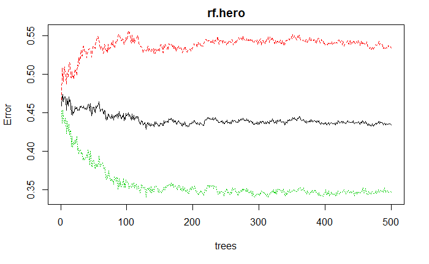

```r
plot(rf.hero)
```

```r
min.tree<-which.min(rf.hero$err.rate[,1])
min.tree
```

```
[1] 129
```

```r
rf.hero2<-randomForest(Team_Won~.,data = trainset,ntree=min.tree)
rf.hero2
```

```
Call:
 randomForest(formula = Team_Won ~ ., data = trainset, ntree = min.tree)
               Type of random forest: classification
                     Number of trees: 129
No. of variables tried at each split: 10

        OOB estimate of  error rate: 44.3%
Confusion matrix:
    -1    1 class.error
-1 649  791   0.5493056
1  577 1071   0.3501214
```

```r
rf.hero.test <- predict(rf.hero2,
                        newdata = testset,
                        type = "response")
confusion.tree<-table(rf.hero.test, testset$Team_Won)
confusion.tree
```

```
rf.hero.test  -1   1
          -1 313 270
          1  401 560
```

```r
(confusion.tree[1,1]+confusion.tree[2,2])/(sum(confusion.tree))
```

```
[1] 0.5654145
```

## Classification based on Win Rate and Pick Rate

```r
#Hero 24 does not have data
Htrain<-train[,c(5:27,29:107,108:117)]
Htest<-test[,c(5:27,29:107,108:117)]
#Pickrate for train data
prtrain<-function(hero){
  for(i in hero){
  hero<-i
  He<-paste("Hero_",hero,sep = "")
  rate<-table(Htrain[,hero])
  PR<-((rate[[1]]+rate[[3]])/(sum(rate[[1]]+rate[[2]]+rate[[3]])))*100
  haha<-data.frame(He,rate[[1]],rate[[2]],rate[[3]],PR)
  colnames(haha)<- c("Hero","Green_Side","Not_Picked","Red_Side","Pickrate")
  return(haha)
  }}
#-----------------------------------------------------------------------------
#Pickrate for test data
prtest<-function(hero){
  for(i in hero){
  hero<-i
  He<-paste("Hero_",hero,sep = "")
  rate<-table(Htest[,hero])
  PR<-((rate[[1]]+rate[[3]])/(sum(rate[[1]]+rate[[2]]+rate[[3]])))*100
  haha<-data.frame(He,rate[[1]],rate[[2]],rate[[3]],PR)
  colnames(haha)<- c("Hero","Green_Side","Not_Picked","Red_Side","Pickrate")
  return(haha)
  }}
```

```r
#Data frame of pickrate for train data
for (i in 1:106) {
  assign(paste("htrain", i, sep = ""), prtrain(i))
}
htrain107<-prtrain(108)
htrain108<-prtrain(109)
htrain109<-prtrain(110)
htrain110<-prtrain(111)
htrain111<-prtrain(112)
```

```r
#Data frame of pickrate for test data
for (i in 1:106) {
  assign(paste("htest", i, sep = ""), prtest(i))
}
htest107<-prtest(108)
htest108<-prtest(109)
htest109<-prtest(110)
htest110<-prtest(111)
htest111<-prtest(112)
```

```r
library(gtools)
#Combining the data frames created from the previous function for the train data
TeamPickTrain<-smartbind(htrain1 , htrain2 , htrain3 , htrain4 , htrain5 , htrain6 , htrain7 , htrain8 , htrain9 , htrain10 ,
    htrain11 , htrain12 , htrain13 , htrain14 , htrain15 , htrain16 , htrain17 , htrain18 , htrain19 , htrain20 ,
    htrain21 , htrain22 , htrain23 , htrain24 , htrain25 , htrain26 , htrain27 , htrain28 , htrain29 , htrain30 ,
    htrain31 , htrain32 , htrain33 , htrain34 , htrain35 , htrain36 , htrain37 , htrain38 , htrain39 , htrain40 ,
    htrain41 , htrain42 , htrain43 , htrain44 , htrain45 , htrain46 , htrain47 , htrain48 , htrain49 , htrain50 ,
    htrain51 , htrain52 , htrain53 , htrain54 , htrain55 , htrain56 , htrain57 , htrain58 , htrain59 , htrain60 ,
    htrain61 , htrain62 , htrain63 , htrain64 , htrain65 , htrain66 , htrain67 , htrain68 , htrain69 , htrain70 ,
    htrain71 , htrain72 , htrain73 , htrain74 , htrain75 , htrain76 , htrain77 , htrain78 , htrain79 , htrain80 ,
    htrain81 , htrain82 , htrain83 , htrain84 , htrain85 , htrain86 , htrain87 , htrain88 , htrain89 , htrain90 ,
    htrain91 , htrain92 , htrain93 , htrain94 , htrain95 , htrain96 , htrain97 , htrain98 , htrain99 , htrain100 ,
    htrain101 , htrain102 , htrain103 , htrain104 , htrain105 , htrain106 , htrain107 , htrain108 , htrain109 ,
    htrain110 , htrain111
)
```

```
the condition has length > 1 and only the first element will be used
```

```r
#---------------------------------------
#Combining the data frames created from the previous function for the test data
TeamPickTest<-smartbind(htest1 , htest2 , htest3 , htest4 , htest5 , htest6 , htest7 , htest8 , htest9 , htest10 ,
    htest11 , htest12 , htest13 , htest14 , htest15 , htest16 , htest17 , htest18 , htest19 , htest20 ,
    htest21 , htest22 , htest23 , htest24 , htest25 , htest26 , htest27 , htest28 , htest29 , htest30 ,
    htest31 , htest32 , htest33 , htest34 , htest35 , htest36 , htest37 , htest38 , htest39 , htest40 ,
    htest41 , htest42 , htest43 , htest44 , htest45 , htest46 , htest47 , htest48 , htest49 , htest50 ,
    htest51 , htest52 , htest53 , htest54 , htest55 , htest56 , htest57 , htest58 , htest59 , htest60 ,
    htest61 , htest62 , htest63 , htest64 , htest65 , htest66 , htest67 , htest68 , htest69 , htest70 ,
    htest71 , htest72 , htest73 , htest74 , htest75 , htest76 , htest77 , htest78 , htest79 , htest80 ,
    htest81 , htest82 , htest83 , htest84 , htest85 , htest86 , htest87 , htest88 , htest89 , htest90 ,
    htest91 , htest92 , htest93 , htest94 , htest95 , htest96 , htest97 , htest98 , htest99 , htest100 ,
    htest101 , htest102 , htest103 , htest104 , htest105 , htest106 , htest107 , htest108 , htest109 ,
    htest110 , htest111
)
```

```
the condition has length > 1 and only the first element will be used
```

```r
TW1<-train[,1]
TW2<-test[,1]
Htrain<-cbind(TW1,Htrain)
Htest<-cbind(TW2,Htest)
```

```r
Hero_Win_Rate_Train<-function(herow)
{
    herow=herow+1
    Red_Win<-filter(Htrain,Htrain$Team_Won==-1 & Htrain[,herow]==-1)
    Red_Loss<-filter(Htrain,Htrain$Team_Won==1 & Htrain[,herow]==-1)
    Green_Win<-filter(Htrain,Htrain$Team_Won==1 & Htrain[,herow]==1)
    Green_Loss<-filter(Htrain,Htrain$Team_Won==-1 & Htrain[,herow]==1)

    RedW<-sum(Red_Win[,herow]==-1)
    GreenW<-sum(Green_Win[,herow]==1)
    Win<-sum(RedW+GreenW)

    RedL<-sum(Red_Loss[,herow]==-1)
    GreenL<-sum(Green_Loss[,herow]==1)
    Loss<-sum(RedL+GreenL)

    Total_Games<-sum(Win+Loss)

    Winrate <- (Win/Total_Games)*100
    print(Winrate)

}
#----------------------------------------------------------------------
Hero_Win_Rate_Test<-function(herow)
{
    herow=herow+1
    Red_Win<-filter(Htest,Htest$Team_Won==-1 & Htest[,herow]==-1)
    Red_Loss<-filter(Htest,Htest$Team_Won==1 & Htest[,herow]==-1)
    Green_Win<-filter(Htest,Htest$Team_Won==1 & Htest[,herow]==1)
    Green_Loss<-filter(Htest,Htest$Team_Won==-1 & Htest[,herow]==1)

    RedW<-sum(Red_Win[,herow]==-1)
    GreenW<-sum(Green_Win[,herow]==1)
    Win<-sum(RedW+GreenW)

    RedL<-sum(Red_Loss[,herow]==-1)
    GreenL<-sum(Green_Loss[,herow]==1)
    Loss<-sum(RedL+GreenL)

    Total_Games<-sum(Win+Loss)

    Winrate <- (Win/Total_Games)*100
    print(Winrate)

}
```

```r
#Had to remove element 107 gave NaN
train_vector<-vector("numeric")
for(i in c(1:106,108:111)){
 train_vector[i]<-Hero_Win_Rate_Train(i)
}
Hwintrain<-data.frame("Win_Rate"=train_vector)
#-------------------------------------------------------------
#Calculating Win Rate for test data
test_vector<-vector("numeric")
for(i in c(1:106,108:111)){
 test_vector[i]<-Hero_Win_Rate_Test(i)
}
Hwintest<-data.frame("Win_Rate"=test_vector)
```

```r
TeamPick_Train<-cbind(TeamPickTrain,Hwintrain)
TeamPick_Test<-cbind(TeamPickTest,Hwintest)
```

```r
head(TeamPick_Train)
```

|  | Hero | Green_Side | Not_Picked | Red_Side | Pickrate | Win_Rate |
| --- | --- | --- | --- | --- | --- | --- |
| 1 | Hero_1 | 7562 | 77677 | 7411 | 16.160820 | 46.69739 |
| 2 | Hero_2 | 10177 | 72386 | 10087 | 21.871560 | 52.70430 |
| 3 | Hero_3 | 1230 | 90126 | 1294 | 2.724231 | 45.00792 |
| 4 | Hero_4 | 5888 | 80948 | 5814 | 12.630329 | 50.75201 |
| 5 | Hero_5 | 5118 | 82600 | 4932 | 10.847275 | 54.76617 |
| 6 | Hero_6 | 10703 | 70950 | 10997 | 23.421479 | 53.47465 |

```r
head(TeamPick_Test)
```

|  | Hero | Green_Side | Not_Picked | Red_Side | Pickrate | Win_Rate |
| --- | --- | --- | --- | --- | --- | --- |
| 1 | Hero_1 | 824 | 8662 | 808 | 15.853895 | 46.69118 |
| 2 | Hero_2 | 1101 | 8062 | 1131 | 21.682534 | 51.70251 |
| 3 | Hero_3 | 154 | 9988 | 152 | 2.972605 | 49.34641 |
| 4 | Hero_4 | 621 | 9052 | 621 | 12.065281 | 50.96618 |
| 5 | Hero_5 | 601 | 9153 | 540 | 11.084127 | 55.21472 |
| 6 | Hero_6 | 1181 | 7925 | 1188 | 23.013406 | 51.07640 |

# K-means

```r
PvsW<-na.omit(TeamPick_Train[,c(5,6)])
```

```r
km_train<-kmeans(PvsW, centers = 5)
km_train_results<-as.factor(km_train$cluster)
```

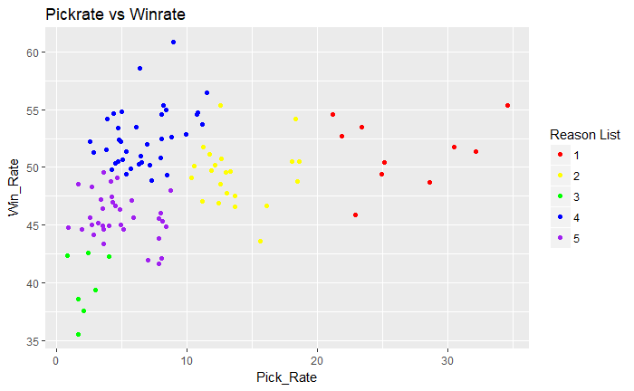

```r
ggplot(PvsW, aes(x=PvsW$Pickrate,y=PvsW$Win_Rate,color=km_train_results)) + geom_point() + labs(title="Pickrate vs Winrate", x="Pick_Rate",y="Win_Rate",color="Reason List") + scale_color_manual(values=c("red","yellow","green","blue","purple"))
```

The points represent different heroes. The colors are seperated by types of heroes.

1. Red: Heroes that are played by the pros. These will usually be picked more often.
2. Yellow: Heroes that are fairly easy to use with a low learning curve.
3. Blue: Heroes who are not picked very often, but the players who pick them play them very well.
4. Purple: Heroes that not many do not want to play. These heroes are most likely picked as a joke.
5. Green: Heroes that are just terrible and should never be played.

## Hierarchical clustering

```r
dist_hero<-dist(PvsW)
hc_hero<-hclust(dist_hero,method = "complete")
```

```r
cut1<-cutree(hc_hero,5)
hc_heror<-as.factor(cut1)
```

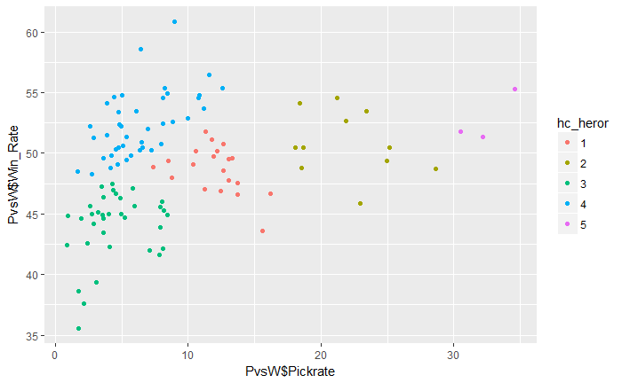

```r
ggplot(PvsW, aes(x=PvsW$Pickrate,y=PvsW$Win_Rate,color=hc_heror)) + geom_point()
```

```r
#This clustering does not really tell me anything. K-means had a better seperation.
```

## Calculating winning team

I am determing the winner based on 5 randomly selected heroes and taking the mean of each side. The team with the higher mean will most likely win the match.

```r
#Selecting 5 Random Heroes to create Red Team and subsetting the Hero name and thier Win rate
Random_Red_Team<-sample_n(TeamPick_Train,5)
Red<-Random_Red_Team[,c(1,6)]
#Selecting 5 Random Heroes to create Green Team and subsetting the Hero name and thier Win rate
Random_Green_Team<-sample_n(TeamPick_Train,5)
Green<-Random_Green_Team[,c(1,6)]
#Mean of the 5 random Heroes for each side
Red_mean<-mean(Red[,2],na.rm=TRUE)
Green_mean<-mean(Green[,2],na.rm = TRUE)
#Determining the probable winning team based on who has the higher Win rate average
if(Red_mean>Green_mean){
  print(paste("There is a",Red_mean,"% Red Team will win"))
}else if (Red_mean==Green_mean){
  print("Draw")
}else
  print(paste("There is a",Green_mean,"% Green Team will win"))
```

```
[1] "There is a 48.702686179828 % Green Team will win"
```

# Conclusion

I was able to predict the outcome of the match around 60% of the time using different methods.The tuned svm model worked slightly better than the rest of the models. The classification using k-means worked effectively, but hierarchical clustering did not work as well. I limited my results by using only 5% of the rows from the original dataset because of how long the rendering took for anything higher.